# Aim of the project

Gerko Vink

# Load packages

```r
set.seed(123)
library(mice)
library(dplyr)
library(magrittr)
library(readr)
```

# Read in the data

The following data are obtained from [Kaggle](https://www.kaggle.com/uciml/pima-indians-diabetes-database)

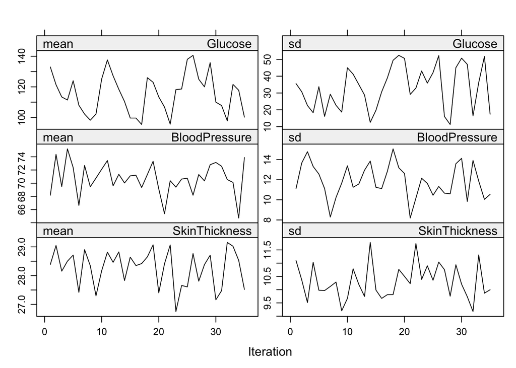

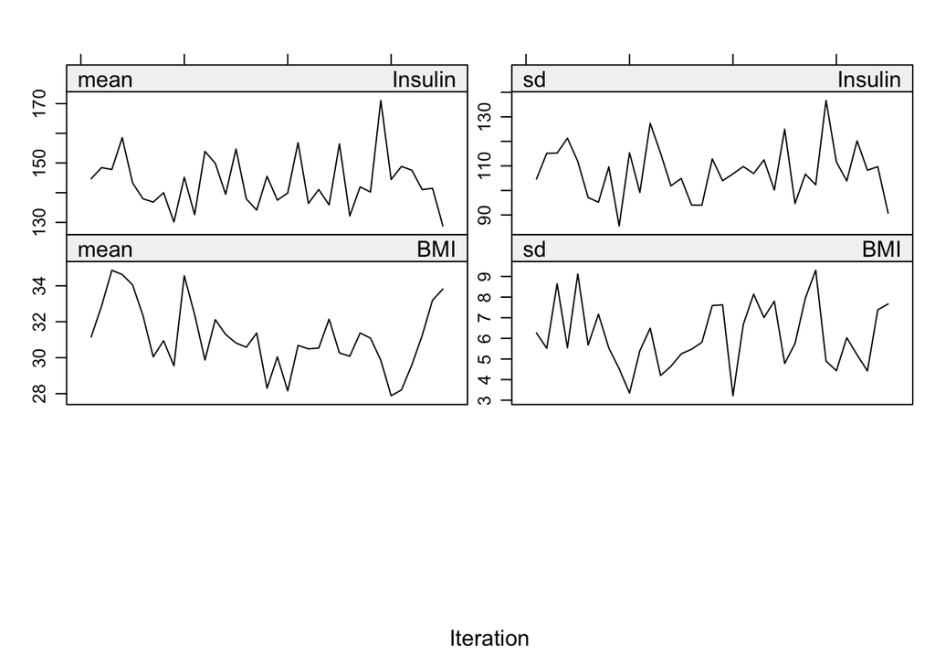

```r
data <- read_csv("Data/diabetes.csv",
                 col_types = cols(Pregnancies = col_integer(),
                                  Glucose = col_integer(),
                                  BloodPressure = col_integer(),
                                  SkinThickness = col_integer(),
                                  Insulin = col_integer(),
                                  Age = col_integer(),
                                  Outcome = col_factor(levels = c("1", "0"))))
data %<>% mutate_at(vars(2:8), na_if, y = 0)
imp <- mice(data, m=1, maxit = 35, method = "pmm", print = FALSE)
plot(imp)
```

```r
data_nozero <- complete(imp)
```

# Aim

The aim of the project is to

1. Formulate an analysis model
2. Run the analysis model on the data set to obtain the *true* data inference
3. Obtain statistical properties of the *true* data set, such as
- `mean()`
- `variance()`
- `cor()`
- etc.
4. Plot the distributions of the *true* data set
5. Simulate `nsim = 1000` times the following:
- 1. synthesize the data $m$ times with `mice`
- 2. calculate the same statistical properties as under (3) on each of the $m$ synthetic sets
- 3. Run the analysis model on each of the $m$ synthetic sets
- 4. Combine the $m$ statistics and parameters from (5b) and (5c) into single inferences
- 5. For each of the $m$ imputed sets, combine half of the imputed set randomly with half of the *true* set, adding an indicator column `Synth_or_True` to identify the true vs. the synthetic rows.
- 6. Run a prediction model that predicts `Synth_or_True ~ .`
- 7. Pool the model parameters over the $m$ sets and record the accuracy
6. Analyze the simulation results by
- 1. Calculating the average parameters and statistics over the `nsim = 1000` simulations
- 2. Plotting the distributions of the statistics and parameters with e.g. boxplots
- 3. Calculating for all statistics and parameters the bootstrap CI.
- 4. Calculating for all parameters the parametric CI cf. Rubin’s rules.
- 5. Calculating the 95% coverage rates of the parameters and statistics (bootstrap CI and parametric CI)
7. Evaluate the results and determine if and when `mice` would yield valid synthetic sets.

# Inspiration

- Study the materials in [this repository](https://github.com/amices/Federated_imputation)

End of document